```python
import pandas as pd
import numpy as np
import math
import ipywidgets as widgets

##Seaborn for fancy plots.
%matplotlib inline
import matplotlib.pyplot as plt
import seaborn as sns


import geopandas as gpd
from shapely.geometry import Point
#import fiona

plt.rcParams['figure.figsize'] = (20, 9)
plt.style.use('Solarize_Light2')

import folium # mapping
from folium.plugins import HeatMap
```

# 1998-2021: Canada Crime Index

Investigate what is the Canadian Crime Index

```python
df_index=pd.read_csv("Crime Index Canada.csv")
# Deleted the following columns as we do not need them.
df_index.drop(['UOM', 'UOM_ID', 'DGUID',
       'SCALAR_FACTOR', 'SCALAR_ID', 'VECTOR', 'COORDINATE', 'STATUS',
       'SYMBOL', 'TERMINATED', 'DECIMALS'], axis=1, inplace =True)

# extract the 'GEO' name and number in separate columns
df_index[['GEO_NAME', 'GEO_NUMBER']] = df_index['GEO'].str.extract(r'([^\[\]]+) \[(\d+)\]')

# drop the original 'GEO' column
df_index.drop('GEO', axis=1, inplace=True)
df_index.drop('GEO_NUMBER', axis=1, inplace=True)

# drop rows where 'GEO_NAME' is null
df_index.dropna(subset=['GEO_NAME'], inplace=True)

# print the updated dataframe
df_index
```

|  | REF_DATE | Statistics | VALUE | GEO_NAME |
| --- | --- | --- | --- | --- |
| 10 | 1998 | Crime severity index | 76.38 | Newfoundland and Labrador |
| 11 | 1998 | Violent crime severity index | 58.43 | Newfoundland and Labrador |
| 12 | 1998 | Non-violent crime severity index | 83.28 | Newfoundland and Labrador |
| 13 | 1998 | Youth crime severity index | 109.72 | Newfoundland and Labrador |
| 14 | 1998 | Youth violent crime severity index | 55.73 | Newfoundland and Labrador |
| ... | ... | ... | ... | ... |
| 19231 | 2021 | Percent change in weighted clearance rate | -8.15 | Nunavut |
| 19232 | 2021 | Violent weighted clearance rate | 74.56 | Nunavut |
| 19233 | 2021 | Percent change in violent weighted clearance rate | -0.48 | Nunavut |
| 19234 | 2021 | Non-violent weighted clearance rate | 46.66 | Nunavut |
| 19235 | 2021 | Percent change in non-violent weighted clearan... | -12.62 | Nunavut |

18409 rows × 4 columns

```python
# convert 'REF_DATE' column to datetime
df_index['REF_DATE'] = pd.to_datetime(df_index['REF_DATE'], format='%Y')
```

```python
df_index.columns
```

```
Index(['REF_DATE', 'Statistics', 'VALUE', 'GEO_NAME'], dtype='object')
```

```python
df_index.info()
```

```
<class 'pandas.core.frame.DataFrame'>
Int64Index: 18409 entries, 10 to 19235
Data columns (total 4 columns):
 #   Column      Non-Null Count  Dtype
---  ------      --------------  -----
 0   REF_DATE    18409 non-null  datetime64[ns]
 1   Statistics  18409 non-null  object
 2   VALUE       15249 non-null  float64
 3   GEO_NAME    18409 non-null  object
dtypes: datetime64[ns](1), float64(1), object(2)
memory usage: 719.1+ KB
```

```python
df_index['Statistics'].value_counts()
```

```
Crime severity index                                        1071
Weighted clearance rate                                     1071
Violent crime severity index                                1071
Non-violent weighted clearance rate                         1071
Violent weighted clearance rate                             1071
Percent change in non-violent weighted clearance rate       1071
Youth non-violent crime severity index                      1071
Youth violent crime severity index                          1071
Youth crime severity index                                  1071
Non-violent crime severity index                            1071
Percent change in crime severity index                      1031
Percent change in violent crime severity index              1031
Percent change in non-violent crime severity index          1031
Percent change in weighted clearance rate                   1031
Percent change in violent weighted clearance rate           1031
Percent change in youth crime severity index                 848
Percent change in youth violent crime severity index         848
Percent change in youth non-violent crime severity index     848
Name: Statistics, dtype: int64
```

```python
# drop any rows with missing values
df_index.dropna(inplace=True)
```

We are only interested in Alberta- lets look at the Crime Index for the two Major Cities, Edmonton & Calgary, compared with the overall Alberta index.

```python
""" Funciton to plot line diagrams over time for Arguments, data, Index Type and the Cities we want to look at as a list."""
def Plot_Crime_Index(data, statistic, *Cities):
    # filter the dataframe to include only Edmonton, Calgary, and Alberta
    data = data[data['GEO_NAME'].isin(Cities)]

    # filter the dataframe to include only 'Violent crime severity index' statistics
    data = data[data['Statistics'] == statistic]

    # filter the dataframe to include only years between 1998 and 2021
    data = data[(data['REF_DATE'] >= '1998-01-01') & (data['REF_DATE'] <= '2021-01-30')]

    # pivot the dataframe to have 'GEO_NAME' as columns and 'REF_DATE' as index
    data_pivot = data.pivot(index='REF_DATE', columns='GEO_NAME', values='VALUE')

    # create the line plot with three separate lines
    ax = data_pivot.plot(kind='line', figsize=(20,10), x_compat=True)

    # set the plot title and axes labels
    ax.set_title(f'{statistic} in Alberta (Edmonton & Calgary) between 1998 and 2021', fontsize = 25)
    ax.set_xlabel('Year')
    ax.set_ylabel('Violent Crime Severity Index')

    # display the plot
    plt.show()
```

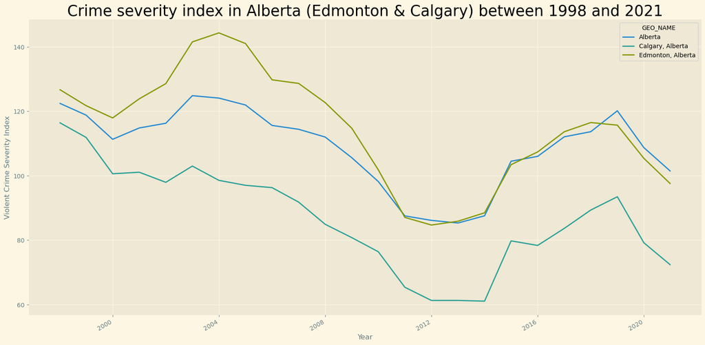

```python
# Over all Crime Severity Index.
cities=['Edmonton, Alberta', 'Calgary, Alberta', 'Alberta']
Plot_Crime_Index(df_index, 'Crime severity index', *cities)
```

> Looking at the Over Crime Severity Index, we see that Edmonton's index (after 2010) was the same as the overall Alberta Index. However, Calgary's index was much lower for all the years.

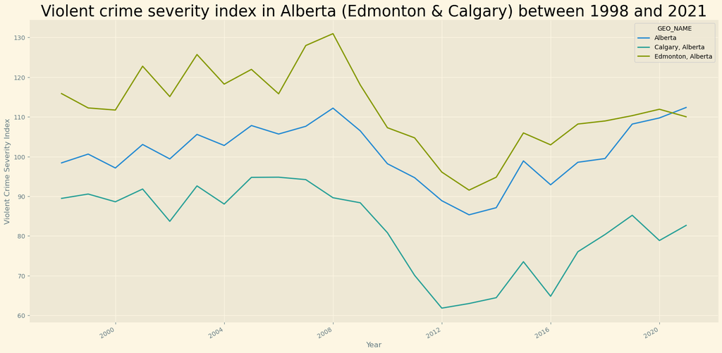

```python
# Violent Crime Severity Index
Plot_Crime_Index(df_index, 'Violent crime severity index', *cities)
```

> So we need to look at why is the Severe Crime Index so much higher for Edmonton?

# 2009-2019: Edmonton Crime data by Neighborhood

### Data: Edmonton Neighborhood-CrimeData-Weather from 2009 to 2019

```python
df=pd.read_csv('neighborhooddata-crimedata-weatherdata.csv', encoding_errors='ignore')
df.rename(columns={'Neighbourhood Name': 'NGH_Name', 'Neighbourhood Number':'NGH_Number'}, inplace=True)
#df.drop(['Month-Year.1', 'Month-Year'], axis=1, inplace =True)
df.drop(['Descriptive Name'], axis=1, inplace =True)
df.drop(['Month-Year.1'], axis=1, inplace =True)
df.drop(['Occurrence Reported Quarter'], axis=1, inplace =True)
df.rename(columns={'Occurrence Violation Type Group': 'Violation_Type', 'Occurrence Reported Month':'Reported_Month', 'Occurrence Reported Year':'Reported_Year'}, inplace=True)
df.rename(columns={'Occurrence Reported Quarter': 'QRT', 'Number of Occurrences':'Sum_Occurrences'}, inplace=True)

df['Month-Year']=pd.to_datetime(df['Month-Year'], format='%b-%y')
df['DT_Year']=df['Month-Year'].dt.year
df['DT_Month']=df['Month-Year'].dt.month_name()
df.drop(['Reported_Year'], axis=1, inplace =True)
df.drop(['Reported_Month'], axis=1, inplace =True)
df.drop(['Month-Year'], axis=1, inplace =True)

df['AVG_Temp']=(df['Air Temp. Avg. Max. (C)']+df['Air Temp. Avg. Min. (C)'])/2
df.drop(['Air Temp. Avg. Min. (C)'], axis=1, inplace =True)
df.drop(['Air Temp. Avg. Max. (C)'], axis=1, inplace =True)
print('Shape: ',df.shape)
print('Total Null Values : ', df.isnull().sum().sum())
print('Columns: ',df.columns)
print()
print('INFO: ', df.info())
print()


df.head(2)
```

```
Shape:  (112121, 9)
Total Null Values :  0
Columns:  Index(['NGH_Name', 'NGH_Number', 'Latitude', 'Longitude', 'Violation_Type',
       'Sum_Occurrences', 'DT_Year', 'DT_Month', 'AVG_Temp'],
      dtype='object')

<class 'pandas.core.frame.DataFrame'>
RangeIndex: 112121 entries, 0 to 112120
Data columns (total 9 columns):
 #   Column           Non-Null Count   Dtype
---  ------           --------------   -----
 0   NGH_Name         112121 non-null  object
 1   NGH_Number       112121 non-null  int64
 2   Latitude         112121 non-null  float64
 3   Longitude        112121 non-null  float64
 4   Violation_Type   112121 non-null  object
 5   Sum_Occurrences  112121 non-null  int64
 6   DT_Year          112121 non-null  int64
 7   DT_Month         112121 non-null  object
 8   AVG_Temp         112121 non-null  float64
dtypes: float64(3), int64(3), object(3)
memory usage: 7.7+ MB
INFO:  None
```

|  | NGH_Name | NGH_Number | Latitude | Longitude | Violation_Type | Sum_Occurrences | DT_Year | DT_Month | AVG_Temp |
| --- | --- | --- | --- | --- | --- | --- | --- | --- | --- |
| 0 | AMBLESIDE | 5505 | 53.430642 | -113.600677 | Break and Enter | 1 | 2015 | May | 10.563387 |
| 1 | ANTHONY HENDAY SOUTH | 4014 | 53.432209 | -113.547667 | Break and Enter | 1 | 2015 | May | 10.563387 |

```python
df['Violation_Type'].value_counts()
```

```
Theft From Vehicle    28993
Break and Enter       24381
Assault               20887
Theft Of Vehicle      20661
Robbery                7651
Sexual Assaults        5766
Theft Over $5000       3549
Homicide                233
Name: Violation_Type, dtype: int64
```

> Filter Data to only Violent Crimes=Assault, Homicide, Sexual Assault, Robbery

```python
# Filter the data to the years 2009-2019
df_filtered = df.loc[(df['DT_Year'] >= 2009) & (df['DT_Year'] <= 2019)]

# Filter the data to only include the desired violation types
violation_types = ['Assault', 'Homicide', 'Sexual Assaults', 'Robbery']
df_filtered = df_filtered.loc[df_filtered['Violation_Type'].isin(violation_types)]
df_filtered
```

|  | NGH_Name | NGH_Number | Latitude | Longitude | Violation_Type | Sum_Occurrences | DT_Year | DT_Month | AVG_Temp |
| --- | --- | --- | --- | --- | --- | --- | --- | --- | --- |
| 32595 | ALLENDALE | 5010 | 53.502277 | -113.504821 | Assault | 1 | 2014 | October | 6.862258 |
| 32596 | ANTHONY HENDAY RAMPART | 4023 | 53.627497 | -113.576375 | Assault | 1 | 2014 | October | 6.862258 |
| 32597 | ASPEN GARDENS | 5020 | 53.477535 | -113.545664 | Assault | 1 | 2014 | October | 6.862258 |
| 32598 | ATHLONE | 3010 | 53.588026 | -113.550982 | Assault | 1 | 2014 | October | 6.862258 |
| 32599 | BALWIN | 2020 | 53.587951 | -113.455075 | Assault | 1 | 2014 | October | 6.862258 |
| ... | ... | ... | ... | ... | ... | ... | ... | ... | ... |
| 112116 | DOWNTOWN | 1090 | 53.539767 | -113.499421 | Assault | 35 | 2015 | March | 0.542581 |
| 112117 | DOWNTOWN | 1090 | 53.539767 | -113.499421 | Assault | 44 | 2015 | April | 5.618000 |
| 112118 | DOWNTOWN | 1090 | 53.539767 | -113.499421 | Assault | 37 | 2015 | May | 10.563387 |
| 112119 | DOWNTOWN | 1090 | 53.539767 | -113.499421 | Assault | 33 | 2015 | June | 16.227167 |
| 112120 | DOWNTOWN | 1090 | 53.539767 | -113.499421 | Assault | 36 | 2015 | July | 18.354516 |

34537 rows × 9 columns

> What is the Total of Violent Crimes in Edmonton, between 2009 and 2019?

```python
# What are the most common types of crimes between 2009 & 2019
most_common_crimes=pd.DataFrame({'Count': df_filtered['Violation_Type'].value_counts().sort_values(ascending=False).head(10)})
most_common_crimes
```

|  | Count |
| --- | --- |
| Assault | 20887 |
| Robbery | 7651 |
| Sexual Assaults | 5766 |
| Homicide | 233 |

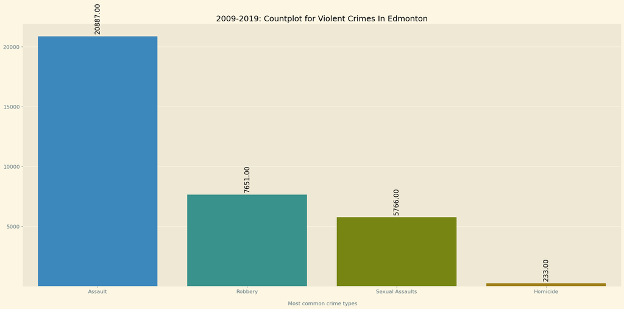

```python
plt.figure(figsize = (20,10))
splot=sns.barplot(x = most_common_crimes.index, y = 'Count', data = most_common_crimes)
# add annotations
for p in splot.patches:
    splot.annotate(format(p.get_height(), '.2f'), (p.get_x() + p.get_width() / 2., p.get_height()),
                   ha='center', va='bottom', fontsize=15, color='black', rotation=90, xytext=(0, 5),
                   textcoords='offset points')
plt.yticks((np.arange(5000, most_common_crimes['Count'].max(), 5000)))
plt.ylabel(None)
plt.tick_params(labelsize = 12)
plt.xlabel('\n Most common crime types', fontsize = 12)
plt.title('2009-2019: Countplot for Violent Crimes In Edmonton', fontsize = 18)
plt.tight_layout()
```

> Looking at the Top 10 Neighborhoods with the highest Violent Crimes in Edmonton, between 2009 and 2019.

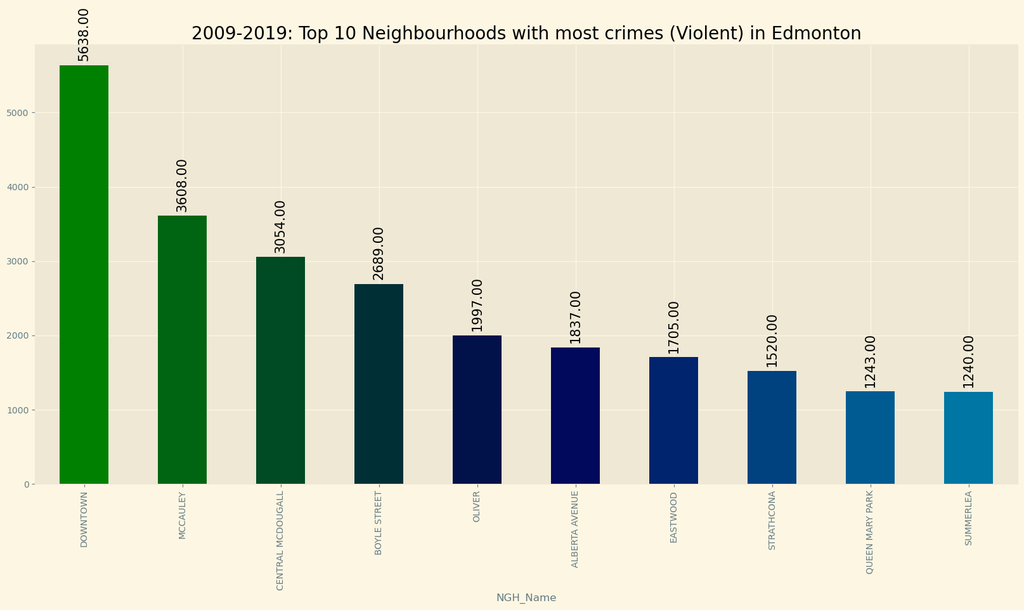

```python
color = plt.cm.ocean(np.linspace(0, 1, 15))
splot=df_filtered.groupby(['NGH_Name'])['Sum_Occurrences'].sum().sort_values(ascending=False).head(10).plot.bar(color=color)
for p in splot.patches:
    splot.annotate(format(p.get_height(), '.2f'), (p.get_x() + p.get_width() / 2., p.get_height()),
                   ha='center', va='bottom', fontsize=15, color='black', rotation=90, xytext=(0, 5),
                   textcoords='offset points')
plt.title('2009-2019: Top 10 Neighbourhoods with most crimes (Violent) in Edmonton',fontsize = 20)
plt.xticks(rotation = 90)
plt.show()
```

```python
top_10=['DOWNTOWN', 'MCCUULEY', 'CENTRAL MCDOUGALL', 'BOYLE STREET',
         'OLIVER', 'ALBERTA AVENUE', 'EASTWOOD', 'STRATHCONA', 'QUEEN MARY PARK', 'SUMMERLEA']
# calculate total sum of occurrences across all neighborhoods
total_occurrences = df['Sum_Occurrences'].sum()

# filter dataframe to only include top 6 neighborhoods
top_10_occurrences = df[df['NGH_Name'].isin(top_10)]['Sum_Occurrences'].sum()

# calculate percentage of total crime held by top 6 neighborhoods
percentage_top_6 = (top_10_occurrences / total_occurrences) * 100

# print the result
print("The top 10 neighborhoods hold {:.2f}% of the overall crime".format(percentage_top_6))
```

```
The top 10 neighborhoods hold 17.91% of the overall crime
```

> Looking at the Top 10 Neighborhoods for every year between 2009 and 2019. Do the same cities show up every year?

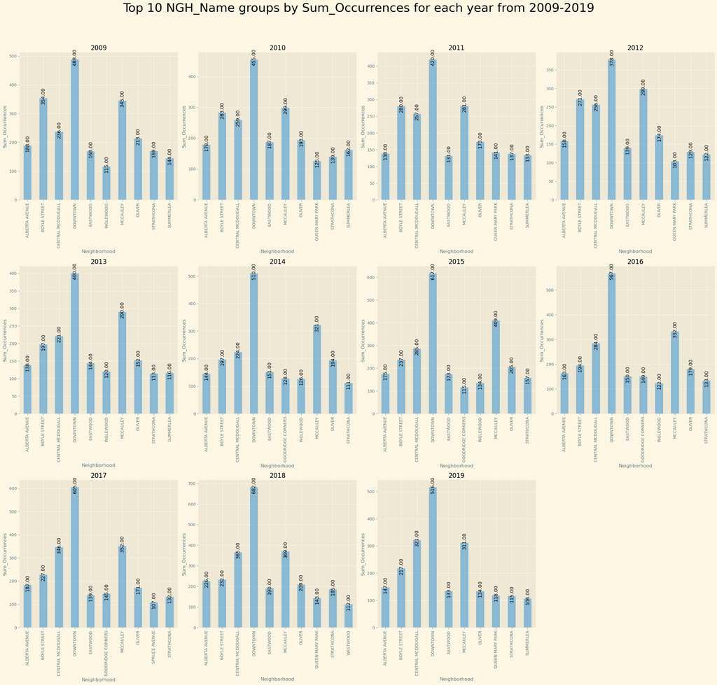

```python
# Define the violation types of interest
#violation_types = ['Assault', 'Homicide', 'Sexual Assaults', 'Robbery']

# Filter the data to the years 2009-2019 and the violation types of interest
#df = df[(df['DT_Year'] >= 2009) & (df['DT_Year'] <= 2019) & (df['Violation_Type'].isin(violation_types))]

# Group the data by year and NGH_Name and compute the Sum_Occurrences
grouped = df_filtered.groupby(['DT_Year', 'NGH_Name'])['Sum_Occurrences'].sum().reset_index()

# Create a list of years to loop over
years = range(2009, 2020)

# Create a 3x4 grid of subplots
fig, axes = plt.subplots(nrows=3, ncols=4, figsize=(25,25))

# Flatten the axes array for easier indexing
axes = axes.flatten()

# Iterate over the years and plot the top 10 NGH_Name groups for each year
for i, year in enumerate(years):
    # Filter the data to the current year
    year_data = grouped[grouped['DT_Year'] == year]

    # Sort the groups by Sum_Occurrences and select the top 10
    top_groups = year_data.groupby('NGH_Name')['Sum_Occurrences'].sum().sort_values(ascending=False).head(10)

    # Filter the data to only include the top 10 groups
    year_data = year_data[year_data['NGH_Name'].isin(top_groups.index)]

    # Pivot the data to create a table with NGH_Name as rows and year as columns
    pivot_table = year_data.pivot(index='NGH_Name', columns='DT_Year', values='Sum_Occurrences')

    # Create a bar plot of the pivot table
    ax = axes[i]
    pivot_table.plot(kind='bar', ax=ax, stacked=True, alpha=0.5, legend=None)
    ax.set_xlabel('Neighborhood')
    ax.set_ylabel('Sum_Occurrences')
    ax.set_title(str(year))
    # add annotations
    for p in ax.patches:
        ax.annotate(format(p.get_height(), '.2f'), (p.get_x() + p.get_width() / 2., p.get_height()),
                    ha='center', va='center', fontsize=12, color='black', rotation=90, xytext=(0, 5),
                    textcoords='offset points')

# Hide any unused subplots
for i in range(len(years), len(axes)):
    fig.delaxes(axes[i])

# Add a main title to the figure
fig.suptitle('Top 10 NGH_Name groups by Sum_Occurrences for each year from 2009-2019', fontsize=30)

# Adjust the layout and spacing of the subplots
fig.tight_layout(rect=[0, 0.03, 1, 0.95])
plt.show()
```

> Its seems that there are some Neighborhoods that keep showing up in the Top10 for every year between 2009 and 2019.

Top 6 Neighborhoods that consistently show up are:

Downtown

Alberta Avenue

Boyle Street

Central McDougall

McCaulley

Oliver

The next 5 Neighborhoods come next, that intermitantly show up in the top 10:

Eastwood

Queen Mary Park

Inglewood

Strathcona

Summerlea

> Lets view the Top 6 a little differently.

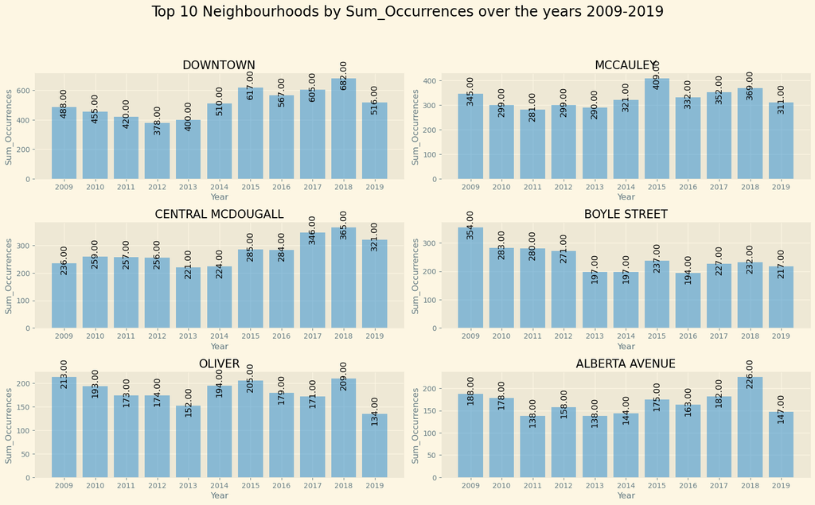

```python
# Define the violation types of interest
#violation_types = ['Assault', 'Homicide', 'Sexual Assaults', 'Robbery']

# Filter the data to the years 2009-2019 and the violation types of interest
#df = df[(df['DT_Year'] >= 2009) & (df['DT_Year'] <= 2019) & (df['Violation_Type'].isin(violation_types))]
# Aggregate the Sum_Occurrences values by NGH_Name and year
grouped = df_filtered.groupby(['NGH_Name', df_filtered['DT_Year']])['Sum_Occurrences'].sum().reset_index()
#grouped = df.groupby(['NGH_Name', df['DT_Year']])['Sum_Occurrences'].sum().sort_values()

# Sort the groups by Sum_Occurrences and select the top 15
top_groups = grouped.groupby('NGH_Name')['Sum_Occurrences'].sum().sort_values(ascending=False).head(6)

# Filter the grouped data to only include the top 15 groups
grouped = grouped[grouped['NGH_Name'].isin(top_groups.index)]

# Pivot the grouped data to create a table with NGH_Name as rows and year as columns
pivot_table = grouped.pivot(index='NGH_Name', columns='DT_Year', values='Sum_Occurrences')

# Create a 4x4 grid of subplots
fig, axes = plt.subplots(nrows=5, ncols=2, figsize=(16, 16))

# Flatten the axes array for easier indexing
axes = axes.flatten()

# Iterate over the top 15 groups and plot each group in a separate subplot
for i, group in enumerate(top_groups.index):
    data = pivot_table.loc[group].values
    ax = axes[i]
    ax.bar(range(11), data, align='center', alpha=0.5)
    ax.set_xticks(range(11))
    ax.set_xticklabels(pivot_table.columns)
    ax.set_xlabel('Year')
    ax.set_ylabel('Sum_Occurrences')
    ax.set_title(group)
    # add annotations
    for p in ax.patches:
        ax.annotate(format(p.get_height(), '.2f'), (p.get_x() + p.get_width() / 2., p.get_height()),
                    ha='center', va='center', fontsize=12, color='black', rotation=90, xytext=(0, 5),
                    textcoords='offset points')

# Hide any unused subplots
for i in range(len(top_groups.index), len(axes)):
    fig.delaxes(axes[i])

# Add a main title to the figure
fig.suptitle('Top 10 Neighbourhoods by Sum_Occurrences over the years 2009-2019', fontsize=20)

# Adjust the layout and spacing of the subplots
fig.tight_layout(rect=[0, 0.03, 1, 0.95])
plt.show()
```

> Looking at the breakdown of Violent Crimes committed within the Top6, which are the most popular neighborhoods every year, between 2009 ad 2019.

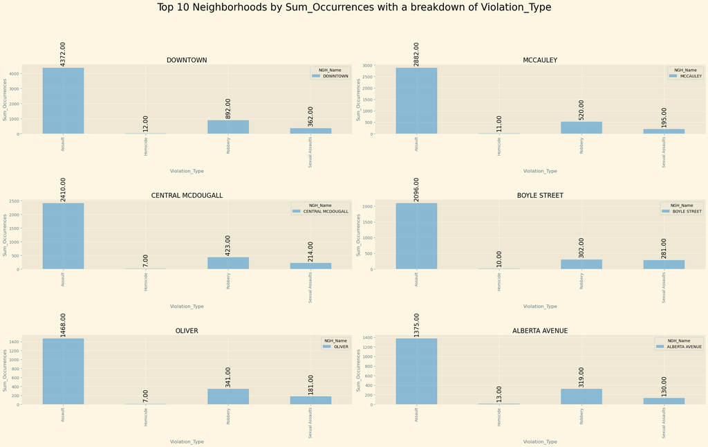

```python
# Define the violation types of interest
#violation_types = ['Assault', 'Homicide', 'Sexual Assaults', 'Robbery']

# Filter the data to the years 2009-2019 and the violation types of interest
#df = df[(df['DT_Year'] >= 2009) & (df['DT_Year'] <= 2019) & (df['Violation_Type'].isin(violation_types))]

# Group the data by Neighborhood and Violation_Type and compute the Sum_Occurrences
grouped = df_filtered.groupby(['NGH_Name', 'Violation_Type'])['Sum_Occurrences'].sum().reset_index()

# Sort the groups by Sum_Occurrences and select the top 8 neighborhoods
top_groups = grouped.groupby('NGH_Name')['Sum_Occurrences'].sum().sort_values(ascending=False).head(6)

# Filter the data to only include the top 8 neighborhoods
grouped = grouped[grouped['NGH_Name'].isin(top_groups.index)]

# Create a 4x4 grid of bar plots, where each plot shows the breakdown of Violation_Type for one of the top 8 neighborhoods
fig, axes = plt.subplots(nrows=5, ncols=2, figsize=(25, 25))

# Flatten the axes array for easier indexing
axes = axes.flatten()

# Iterate over the top 8 neighborhoods and create a bar plot for each one
for i, group in enumerate(top_groups.index):
    # Filter the data to the current neighborhood
    group_data = grouped[grouped['NGH_Name'] == group]

    # Pivot the data to create a table with Violation_Type as rows and Neighborhood as columns
    pivot_table = group_data.pivot(index='Violation_Type', columns='NGH_Name', values='Sum_Occurrences')

    # Create a bar plot of the pivot table
    ax = axes[i]
    pivot_table.plot(kind='bar', ax=ax, alpha=0.5)
    ax.set_xlabel('Violation_Type')
    ax.set_ylabel('Sum_Occurrences')
    ax.set_title(group)

    # add annotations
    for p in ax.patches:
        ax.annotate(format(p.get_height(), '.2f'), (p.get_x() + p.get_width() / 2., p.get_height()),
                    ha='center', va='bottom', fontsize=15, color='black', rotation=90, xytext=(0, 5),
                    textcoords='offset points')

# Hide any unused subplots
for i in range(len(top_groups.index), len(axes)):
    fig.delaxes(axes[i])

# Add a main title to the figure
fig.suptitle('Top 10 Neighborhoods by Sum_Occurrences with a breakdown of Violation_Type', fontsize=25)

# Adjust the layout and spacing of the subplots
fig.tight_layout(rect=[0, 0.03, 1, 0.95])

plt.show()
```

> Pivot df_filtered

```python
# Create a pivot table that shows the total number of occurrences for each violation type in each neighborhood
pivoted_df_filtered= pd.pivot_table(df_filtered, index=['NGH_Name', 'NGH_Number', 'Latitude', 'Longitude', 'AVG_Temp', 'DT_Year', 'DT_Month'], columns='Violation_Type', values='Sum_Occurrences', aggfunc='sum', fill_value=0)
pivoted_df_filtered = pivoted_df_filtered.reset_index()
pivoted_df_filtered
```

| Violation_Type | NGH_Name | NGH_Number | Latitude | Longitude | AVG_Temp | DT_Year | DT_Month | Assault | Homicide | Robbery | Sexual Assaults |
| --- | --- | --- | --- | --- | --- | --- | --- | --- | --- | --- | --- |
| 0 | ABBOTTSFIELD | 2010 | 53.574143 | -113.388758 | -20.763214 | 2019 | February | 3 | 0 | 0 | 0 |
| 1 | ABBOTTSFIELD | 2010 | 53.574143 | -113.388758 | -17.671935 | 2009 | December | 3 | 0 | 1 | 0 |
| 2 | ABBOTTSFIELD | 2010 | 53.574143 | -113.388758 | -16.388929 | 2014 | February | 4 | 0 | 0 | 1 |
| 3 | ABBOTTSFIELD | 2010 | 53.574143 | -113.388758 | -15.673710 | 2012 | December | 7 | 0 | 0 | 0 |
| 4 | ABBOTTSFIELD | 2010 | 53.574143 | -113.388758 | -14.465968 | 2010 | December | 2 | 1 | 0 | 0 |
| ... | ... | ... | ... | ... | ... | ... | ... | ... | ... | ... | ... |
| 23884 | YOUNGSTOWN INDUSTRIAL | 4660 | 53.552476 | -113.610588 | 15.504839 | 2011 | August | 1 | 0 | 0 | 0 |
| 23885 | YOUNGSTOWN INDUSTRIAL | 4660 | 53.552476 | -113.610588 | 16.247581 | 2009 | July | 1 | 0 | 0 | 0 |
| 23886 | YOUNGSTOWN INDUSTRIAL | 4660 | 53.552476 | -113.610588 | 16.505484 | 2014 | August | 0 | 0 | 1 | 0 |
| 23887 | YOUNGSTOWN INDUSTRIAL | 4660 | 53.552476 | -113.610588 | 17.485806 | 2018 | July | 1 | 0 | 0 | 0 |
| 23888 | YOUNGSTOWN INDUSTRIAL | 4660 | 53.552476 | -113.610588 | 18.354516 | 2015 | July | 0 | 0 | 1 | 0 |

23889 rows × 11 columns

```python
print('2009-2019: Average of Assaults: ', pivoted_df_filtered['Assault'].mean())
print('2009-2019: Average of Homicide: ', pivoted_df_filtered['Homicide'].mean())
print('2009-2019: Average of Robbery: ', pivoted_df_filtered['Robbery'].mean())
print('2009-2019: Average of Sexual Assaults: ', pivoted_df_filtered['Sexual Assaults'].mean())
```

```
2009-2019: Average of Assaults:  2.5423835237975636
2009-2019: Average of Homicide:  0.009837163548076521
2009-2019: Average of Robbery:  0.5177278245217464
2009-2019: Average of Sexual Assaults:  0.30980786135878435
```

```python
top_ngh=['DOWNTOWN', 'MCCAULEY', 'CENTRAL MCDOUGALL', 'BOYLE STREET', 'OLIVER', 'ALBERTA AVENUE']
```

```python
top_10=['DOWNTOWN', 'MCCUULEY', 'CENTRAL MCDOUGALL', 'BOYLE STREET',
         'OLIVER', 'ALBERTA AVENUE', 'EASTWOOD', 'STRATHCONA', 'QUEEN MARY PARK', 'SUMMERLEA']
```

## Visualizing the Violent Crimes in Edmonton with Folium and Geopandas

Foluim Heat Map

```python
# Folium
location_of_most_common_crimes = df_filtered[df_filtered['Violation_Type'].isin(most_common_crimes.index)].loc[:, ['Latitude', 'Longitude']].dropna()

my_map=folium.Map(location = [53.4,-113.07], #Initiate map on Boston city
                  zoom_start = 11,
                  min_zoom = 11
)

#HeatMap(data=location_of_most_common_crimes.sample(10000), radius=16).add_to(my_map)
HeatMap(data=location_of_most_common_crimes, radius=16).add_to(my_map)


my_map
```

[interactive chart not shown]

Geopandas

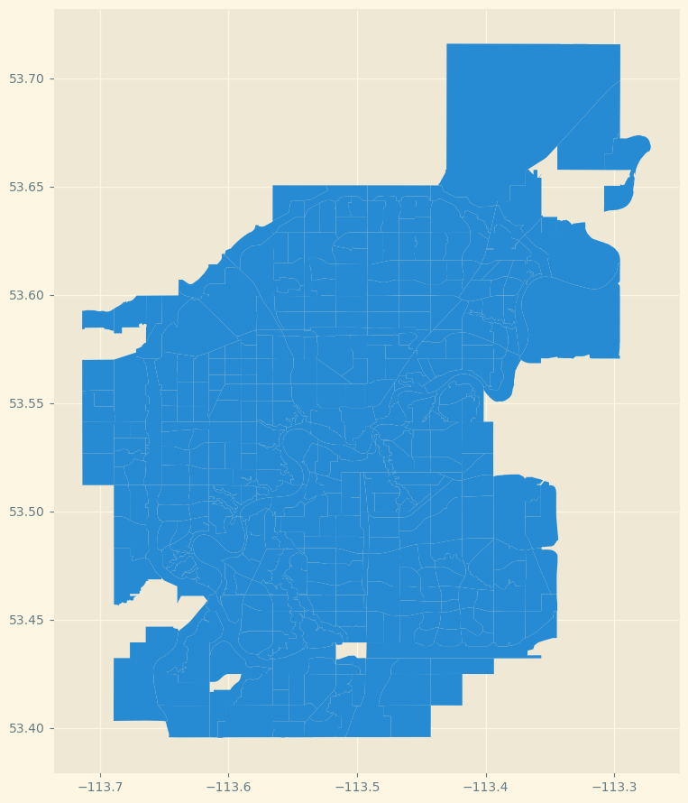

```python
# Using Geopandas
# first need to get out edmonton/neighbourhoods shape file..and change the columns to match our datafile
#https://data.edmonton.ca/Geospatial-Boundaries/2016-Federal-Census-Neighbourhoods-as-of-Official-/3did-mjnj
edmonton_shp=gpd.read_file('geo_export_67517c45-71c1-4f9b-8051-9eaf76457140.shp', geometry='geometry')
edmonton_shp.rename(columns={'name': 'NGH_Name', 'neighbourh': 'NGH_Number'}, inplace=True)
edmonton_shp.drop(['descriptiv', 'date_effec', 'time_effec', 'date_eff_2', 'time_eff_2', 'descriptio'], axis=1, inplace =True)
edmonton_shp.head()
edmonton_shp.plot()
plt.tight_layout()
```

```python
Neighborhoods=pd.DataFrame({'Count':df_filtered['NGH_Name'].value_counts().sort_values(ascending=False)})
Neighborhoods.head(10)
```

|  | Count |
| --- | --- |
| DOWNTOWN | 391 |
| BOYLE STREET | 371 |
| MCCAULEY | 366 |
| CENTRAL MCDOUGALL | 359 |
| OLIVER | 354 |
| ALBERTA AVENUE | 340 |
| EASTWOOD | 320 |
| STRATHCONA | 316 |
| SUMMERLEA | 311 |
| INGLEWOOD | 298 |

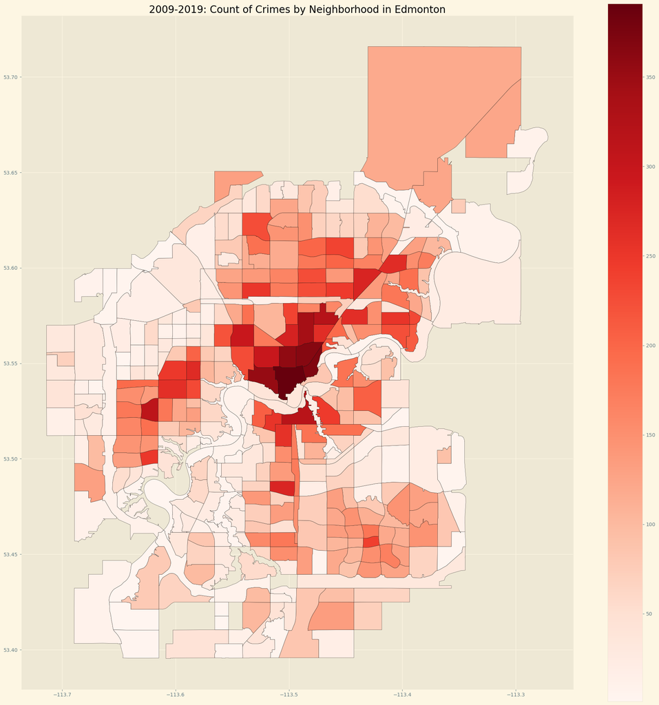

```python
edmonton_shp['Number_Crimes'] = edmonton_shp['NGH_Name'].map(Neighborhoods['Count']) # use map function to match each district with its corresponding value
# This takes the number of times each individual NGH_Name shows up and creates a column Crimes in edmonton_shp
ax = edmonton_shp.plot(column = edmonton_shp['Number_Crimes'], cmap = 'Reds', legend = True, edgecolor = 'black', linewidth = 0.3, figsize = (20,20))
#add_label()
plt.title('2009-2019: Count of Crimes by Neighborhood in Edmonton', fontsize = 20)
plt.tight_layout()
```